# CaseStudy2

Luis Garcia

2022-12-12

# Turn categorical variables to numeric ordinal and plot of the variables with highest correlation

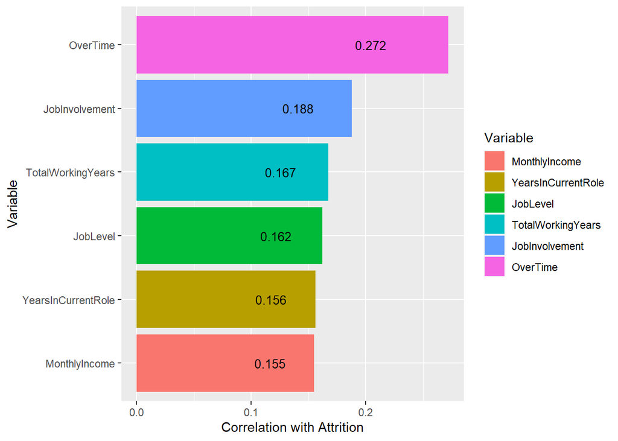

#### The correlations may be misleading since we coerced categorical variables to be numeric regardless of it made sense

# Conduct pearson correlation test variable is continuos, spearman’s if variable is ordinal, and a chi-square test if it’s categorical

```r
cor.test(data$Attrition, data$Age) # Age 9.658e-06
```

```
##
##  Pearson's product-moment correlation
##
## data:  data$Attrition and data$Age
## t = -4.4511, df = 868, p-value = 9.658e-06
## alternative hypothesis: true correlation is not equal to 0
## 95 percent confidence interval:
##  -0.21372723 -0.08374938
## sample estimates:
##        cor
## -0.1493836
```

```r
chisq.test(data$Attrition, data$BusinessTravel) # BusinessTravel 0.04993
```

```
##
##  Pearson's Chi-squared test
##
## data:  data$Attrition and data$BusinessTravel
## X-squared = 5.9945, df = 2, p-value = 0.04993
```

```r
cor.test(data$Attrition, data$DailyRate) # Daily rate 0.3194
```

```
##
##  Pearson's product-moment correlation
##
## data:  data$Attrition and data$DailyRate
## t = -0.99618, df = 868, p-value = 0.3194
## alternative hypothesis: true correlation is not equal to 0
## 95 percent confidence interval:
##  -0.10003417  0.03274616
## sample estimates:
##         cor
## -0.03379312
```

```r
chisq.test(data$Attrition, data$Department) # Department 0.009424
```

```
##
##  Pearson's Chi-squared test
##
## data:  data$Attrition and data$Department
## X-squared = 9.329, df = 2, p-value = 0.009424
```

```r
cor.test(data$Attrition, data$DistanceFromHome) # DistanceFromHome .01013
```

```
##
##  Pearson's product-moment correlation
##
## data:  data$Attrition and data$DistanceFromHome
## t = 2.577, df = 868, p-value = 0.01013
## alternative hypothesis: true correlation is not equal to 0
## 95 percent confidence interval:
##  0.02079097 0.15271755
## sample estimates:
##        cor
## 0.08713629
```

```r
cor.test(data$Attrition, data$Education, method = 'spearman') # Education 0.1328
```

```
##
##  Spearman's rank correlation rho
##
## data:  data$Attrition and data$Education
## S = 115348245, p-value = 0.1328
## alternative hypothesis: true rho is not equal to 0
## sample estimates:
##         rho
## -0.05100567
```

```r
chisq.test(data$Attrition, data$EducationField) # 0.2682
```

```
##
##  Pearson's Chi-squared test
##
## data:  data$Attrition and data$EducationField
## X-squared = 6.4114, df = 5, p-value = 0.2682
```

```r
#chisq.test(data$Attrition, data$EmployeeCount) # NoVariation, null?
chisq.test(data$Attrition, data$EmployeeNumber) # EmployeeNumber 0.4841
```

```
##
##  Pearson's Chi-squared test
##
## data:  data$Attrition and data$EmployeeNumber
## X-squared = 870, df = 869, p-value = 0.4841
```

```r
cor.test(data$Attrition, data$EnvironmentSatisfaction, method = 'spearman') # EnvironmentSatisfaction 0.03838
```

```
##
##  Spearman's rank correlation rho
##
## data:  data$Attrition and data$EnvironmentSatisfaction
## S = 117457181, p-value = 0.03838
## alternative hypothesis: true rho is not equal to 0
## sample estimates:
##         rho
## -0.07022143
```

```r
chisq.test(data$Attrition, data$Gender) # Gender 0.5151
```

```
##
##  Pearson's Chi-squared test with Yates' continuity correction
##
## data:  data$Attrition and data$Gender
## X-squared = 0.42363, df = 1, p-value = 0.5151
```

```r
cor.test(data$Attrition, data$HourlyRate) # HourlyRate 0.2815
```

```
##
##  Pearson's product-moment correlation
##
## data:  data$Attrition and data$HourlyRate
## t = 1.0777, df = 868, p-value = 0.2815
## alternative hypothesis: true correlation is not equal to 0
## 95 percent confidence interval:
##  -0.0299844  0.1027702
## sample estimates:
##        cor
## 0.03655418
```

```r
cor.test(data$Attrition, data$JobInvolvement, method = 'spearman') # JobInvolvement 6.587e-07
```

```
##
##  Spearman's rank correlation rho
##
## data:  data$Attrition and data$JobInvolvement
## S = 128150276, p-value = 6.587e-07
## alternative hypothesis: true rho is not equal to 0
## sample estimates:
##        rho
## -0.1676525
```

```r
cor.test(data$Attrition, data$JobLevel, method = 'spearman') # JobLevel 1.912e-08
```

```
##
##  Spearman's rank correlation rho
##
## data:  data$Attrition and data$JobLevel
## S = 130501798, p-value = 1.912e-08
## alternative hypothesis: true rho is not equal to 0
## sample estimates:
##        rho
## -0.1890786
```

```r
chisq.test(data$Attrition, data$JobRole) # JobRole 3.647e-10
```

```
##
##  Pearson's Chi-squared test
##
## data:  data$Attrition and data$JobRole
## X-squared = 60.543, df = 8, p-value = 3.647e-10
```

```r
cor.test(data$Attrition, data$JobSatisfaction, method = 'spearman') # JobSatisfaction 0.001153
```

```
##
##  Spearman's rank correlation rho
##
## data:  data$Attrition and data$JobSatisfaction
## S = 121824985, p-value = 0.001153
## alternative hypothesis: true rho is not equal to 0
## sample estimates:
##       rho
## -0.110019
```

```r
chisq.test(data$Attrition, data$MaritalStatus) # MaritalStatus 3.379e-08
```

```
##
##  Pearson's Chi-squared test
##
## data:  data$Attrition and data$MaritalStatus
## X-squared = 34.406, df = 2, p-value = 3.379e-08
```

```r
cor.test(data$Attrition, data$MonthlyIncome) # MonthlyIncome 4.422e-06
```

```
##
##  Pearson's product-moment correlation
##
## data:  data$Attrition and data$MonthlyIncome
## t = -4.6199, df = 868, p-value = 4.422e-06
## alternative hypothesis: true correlation is not equal to 0
## 95 percent confidence interval:
##  -0.21912446 -0.08936942
## sample estimates:
##       cor
## -0.154915
```

```r
cor.test(data$Attrition, data$MonthlyRate) # MonthlyRate 0.2027
```

```
##
##  Pearson's product-moment correlation
##
## data:  data$Attrition and data$MonthlyRate
## t = -1.2749, df = 868, p-value = 0.2027
## alternative hypothesis: true correlation is not equal to 0
## 95 percent confidence interval:
##  -0.10938360  0.02330051
## sample estimates:
##         cor
## -0.04323217
```

```r
cor.test(data$Attrition, data$NumCompaniesWorked) # NumCompanies worked 0.07204
```

```
##
##  Pearson's product-moment correlation
##
## data:  data$Attrition and data$NumCompaniesWorked
## t = 1.8011, df = 868, p-value = 0.07204
## alternative hypothesis: true correlation is not equal to 0
## 95 percent confidence interval:
##  -0.005469025  0.126969672
## sample estimates:
##        cor
## 0.06101889
```

```r
#chisq.test(data$Attrition, data$Over18) # NoVariation null?
chisq.test(data$Attrition,data$OverTime) # OVerTime 2.333e-15
```

```
##
##  Pearson's Chi-squared test with Yates' continuity correction
##
## data:  data$Attrition and data$OverTime
## X-squared = 62.762, df = 1, p-value = 2.333e-15
```

```r
cor.test(data$Attrition, data$PercentSalaryHike) # PercentSalaryHike 0.6516
```

```
##
##  Pearson's product-moment correlation
##
## data:  data$Attrition and data$PercentSalaryHike
## t = 0.45165, df = 868, p-value = 0.6516
## alternative hypothesis: true correlation is not equal to 0
## 95 percent confidence interval:
##  -0.05118981  0.08171055
## sample estimates:
##        cor
## 0.01532807
```

```r
cor.test(data$Attrition, data$PerformanceRating, method = 'spearman') # PerformanceRating 0.6515
```

```
##
##  Spearman's rank correlation rho
##
## data:  data$Attrition and data$PerformanceRating
## S = 108067461, p-value = 0.6515
## alternative hypothesis: true rho is not equal to 0
## sample estimates:
##        rho
## 0.01533384
```

```r
cor.test(data$Attrition, data$RelationshipSatisfaction, method = 'spearman') # RelationshipSatisfaction 0.298
```

```
##
##  Spearman's rank correlation rho
##
## data:  data$Attrition and data$RelationshipSatisfaction
## S = 113627511, p-value = 0.298
## alternative hypothesis: true rho is not equal to 0
## sample estimates:
##         rho
## -0.03532705
```

```r
cor.test(data$Attrition, data$StandardHours) # NoVariation null?
```

```
##
##  Pearson's product-moment correlation
##
## data:  data$Attrition and data$StandardHours
## t = NA, df = 868, p-value = NA
## alternative hypothesis: true correlation is not equal to 0
## 95 percent confidence interval:
##  NA NA
## sample estimates:
## cor
##  NA
```

```r
cor.test(data$Attrition, data$StockOptionLevel, method = 'spearman') # StockOptionLevel 2.18e-09
```

```
##
##  Spearman's rank correlation rho
##
## data:  data$Attrition and data$StockOptionLevel
## S = 131819270, p-value = 2.18e-09
## alternative hypothesis: true rho is not equal to 0
## sample estimates:
##        rho
## -0.2010829
```

```r
cor.test(data$Attrition, data$TotalWorkingYears) # TotalWorkingYears 7.059e-07
```

```
##
##  Pearson's product-moment correlation
##
## data:  data$Attrition and data$TotalWorkingYears
## t = -4.9965, df = 868, p-value = 7.059e-07
## alternative hypothesis: true correlation is not equal to 0
## 95 percent confidence interval:
##  -0.2311035 -0.1018725
## sample estimates:
##        cor
## -0.1672061
```

```r
cor.test(data$Attrition, data$TrainingTimesLastYear) # TrainingTimesLastYear 0.06441
```

```
##
##  Pearson's product-moment correlation
##
## data:  data$Attrition and data$TrainingTimesLastYear
## t = -1.8517, df = 868, p-value = 0.06441
## alternative hypothesis: true correlation is not equal to 0
## 95 percent confidence interval:
##  -0.1286554  0.0037553
## sample estimates:
##         cor
## -0.06272609
```

```r
cor.test(data$Attrition, data$WorkLifeBalance, method = 'spearman') # WorkLifeBalance 0.03434
```

```
##
##  Spearman's rank correlation rho
##
## data:  data$Attrition and data$WorkLifeBalance
## S = 117625305, p-value = 0.03434
## alternative hypothesis: true rho is not equal to 0
## sample estimates:
##        rho
## -0.0717533
```

```r
cor.test(data$Attrition, data$YearsAtCompany) # YearsAtCompany 0.00014
```

```
##
##  Pearson's product-moment correlation
##
## data:  data$Attrition and data$YearsAtCompany
## t = -3.8252, df = 868, p-value = 0.00014
## alternative hypothesis: true correlation is not equal to 0
## 95 percent confidence interval:
##  -0.19356333 -0.06282598
## sample estimates:
##        cor
## -0.1287541
```

```r
cor.test(data$Attrition, data$YearsInCurrentRole) # YearsInCurrentRole 3.665e-06
```

```
##
##  Pearson's product-moment correlation
##
## data:  data$Attrition and data$YearsInCurrentRole
## t = -4.6596, df = 868, p-value = 3.665e-06
## alternative hypothesis: true correlation is not equal to 0
## 95 percent confidence interval:
##  -0.22039310 -0.09069163
## sample estimates:
##        cor
## -0.1562157
```

```r
cor.test(data$Attrition, data$YearsSinceLastPromotion) # YearsSinceLastPromotion 0.8928
```

```
##
##  Pearson's product-moment correlation
##
## data:  data$Attrition and data$YearsSinceLastPromotion
## t = -0.13474, df = 868, p-value = 0.8928
## alternative hypothesis: true correlation is not equal to 0
## 95 percent confidence interval:
##  -0.07101747  0.06191123
## sample estimates:
##          cor
## -0.004573321
```

```r
cor.test(data$Attrition, data$YearsWithCurrManager) # YearsWithCurrentManagaer 1.381e-05
```

```
##
##  Pearson's product-moment correlation
##
## data:  data$Attrition and data$YearsWithCurrManager
## t = -4.3718, df = 868, p-value = 1.381e-05
## alternative hypothesis: true correlation is not equal to 0
## 95 percent confidence interval:
##  -0.2111876 -0.0811078
## sample estimates:
##        cor
## -0.1467822
```

#### Three lowest p-values belonged to OverTime, JobRole, and StockOptionLevel

# Show that the variables with lowest p-value had an effect on Attrtion.

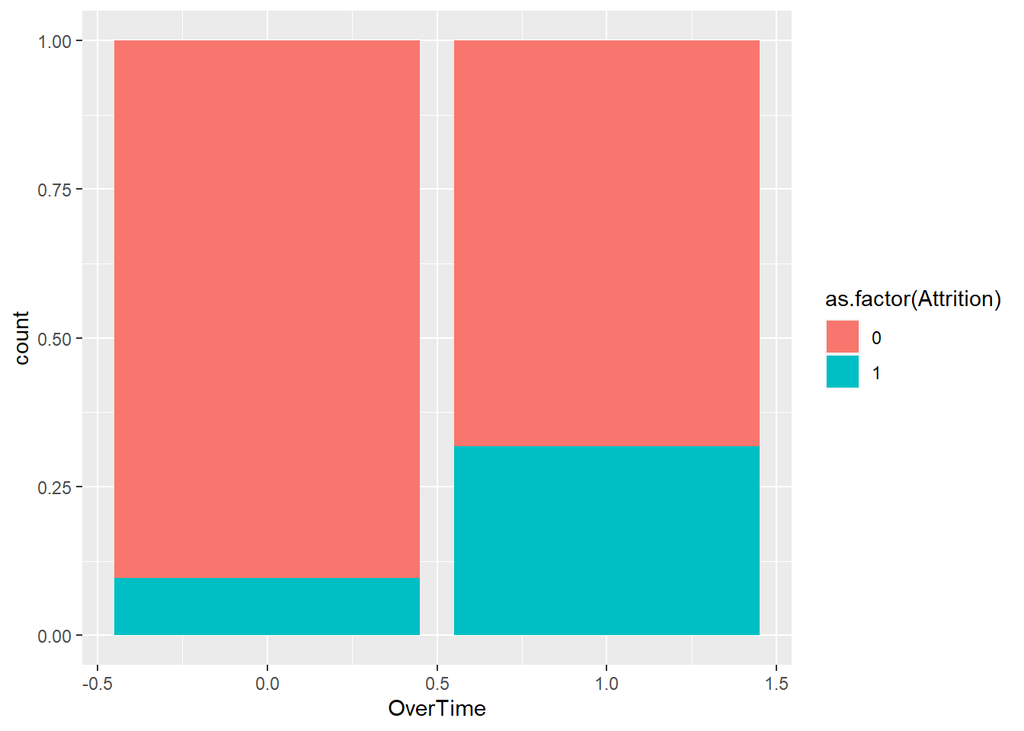

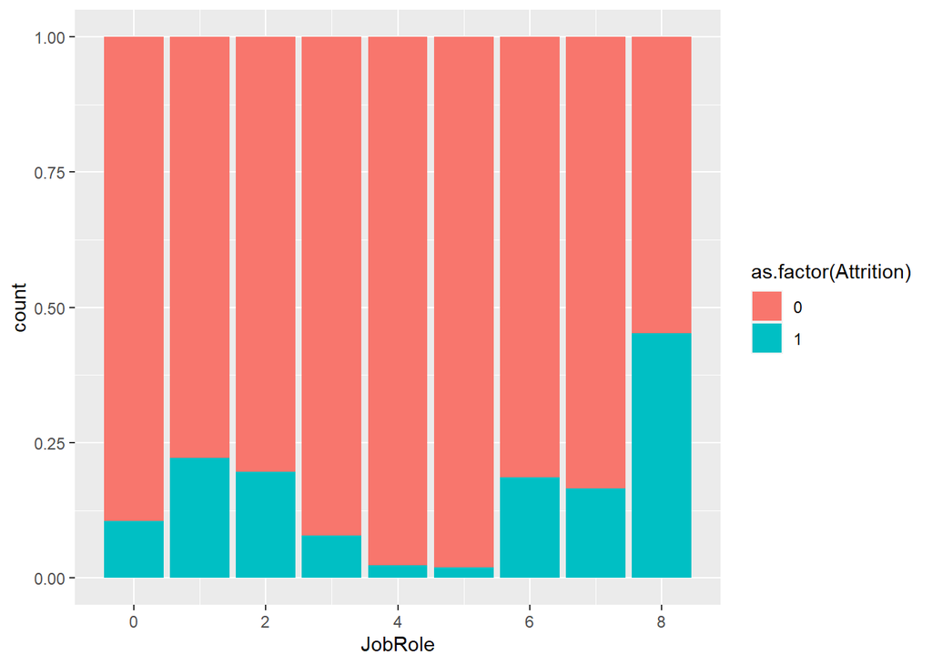

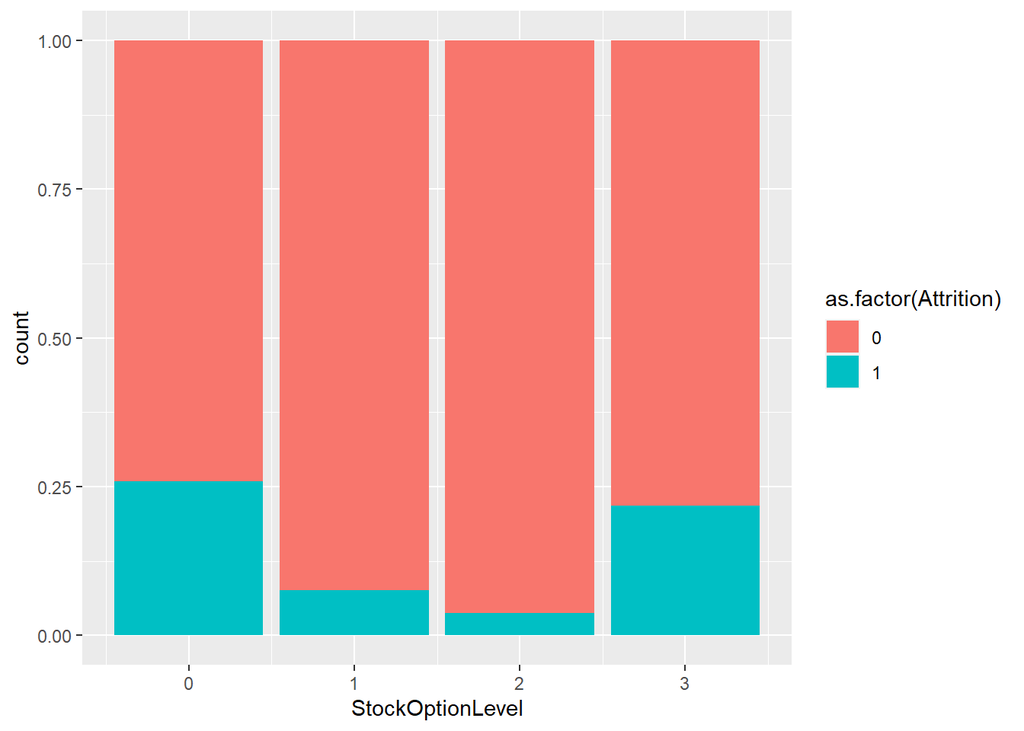

#### OverTime, JobRole, and StockOptionLevel all show changes in attrition based on their levels